# Análise Univariada para Variáveis Qualitativas e Discretas

# Carregando o pacote tidyverse

Nesta aula, iremos explorar a base de dados `mtcars` para realizar análises univariadas de variáveis qualitativas e discretas. Começaremos carregando o pacote `tidyverse`, que inclui o `ggplot2`.

```r
library(tidyverse)
```

# Base de dados `mtcars`

Vamos utilizar a base de dados `mtcars`, que contém dados sobre o desempenho de diferentes modelos de carros, como milhas por galão, número de cilindros, potência, entre outras.

```r
# Carregando e visualizando a base de dados mtcars
data(mtcars)
tb <- as_tibble(mtcars)
glimpse(tb)
```

```
Rows: 32
Columns: 11
$ mpg  <dbl> 21.0, 21.0, 22.8, 21.4, 18.7, 18.1, 14.3, 24.4, 22.8, 19.2, 17.8, 16.4, 17.3, 15.2, 10.4, 10.4, 14.7, 32.4, 30.4, 33.9, 21.5, 15…
$ cyl  <dbl> 6, 6, 4, 6, 8, 6, 8, 4, 4, 6, 6, 8, 8, 8, 8, 8, 8, 4, 4, 4, 4, 8, 8, 8, 8, 4, 4, 4, 8, 6, 8, 4
$ disp <dbl> 160.0, 160.0, 108.0, 258.0, 360.0, 225.0, 360.0, 146.7, 140.8, 167.6, 167.6, 275.8, 275.8, 275.8, 472.0, 460.0, 440.0, 78.7, 75.…
$ hp   <dbl> 110, 110, 93, 110, 175, 105, 245, 62, 95, 123, 123, 180, 180, 180, 205, 215, 230, 66, 52, 65, 97, 150, 150, 245, 175, 66, 91, 11…
$ drat <dbl> 3.90, 3.90, 3.85, 3.08, 3.15, 2.76, 3.21, 3.69, 3.92, 3.92, 3.92, 3.07, 3.07, 3.07, 2.93, 3.00, 3.23, 4.08, 4.93, 4.22, 3.70, 2.…
$ wt   <dbl> 2.620, 2.875, 2.320, 3.215, 3.440, 3.460, 3.570, 3.190, 3.150, 3.440, 3.440, 4.070, 3.730, 3.780, 5.250, 5.424, 5.345, 2.200, 1.…
$ qsec <dbl> 16.46, 17.02, 18.61, 19.44, 17.02, 20.22, 15.84, 20.00, 22.90, 18.30, 18.90, 17.40, 17.60, 18.00, 17.98, 17.82, 17.42, 19.47, 18…
$ vs   <dbl> 0, 0, 1, 1, 0, 1, 0, 1, 1, 1, 1, 0, 0, 0, 0, 0, 0, 1, 1, 1, 1, 0, 0, 0, 0, 1, 0, 1, 0, 0, 0, 1
$ am   <dbl> 1, 1, 1, 0, 0, 0, 0, 0, 0, 0, 0, 0, 0, 0, 0, 0, 0, 1, 1, 1, 0, 0, 0, 0, 0, 1, 1, 1, 1, 1, 1, 1
$ gear <dbl> 4, 4, 4, 3, 3, 3, 3, 4, 4, 4, 4, 3, 3, 3, 3, 3, 3, 4, 4, 4, 3, 3, 3, 3, 3, 4, 5, 5, 5, 5, 5, 4
$ carb <dbl> 4, 4, 1, 1, 2, 1, 4, 2, 2, 4, 4, 3, 3, 3, 4, 4, 4, 1, 2, 1, 1, 2, 2, 4, 2, 1, 2, 2, 4, 6, 8, 2
```

Verifique na base a presença de valores ausentes:

```r
# Verificando a presença de valores ausentes
tb %>%
    summarise_all(~sum(is.na(.))) %>%
    t()
```

```
     [,1]
mpg     0
cyl     0
disp    0
hp      0
drat    0
wt      0
qsec    0
vs      0
am      0
gear    0
carb    0
```

Essa função verifica se há valores ausentes em cada coluna da base de dados `mtcars`. Se houver valores ausentes, o código irá somar a quantidade de `NA`s em cada coluna e exibir o resultado.

## Manipulação de Variáveis

Vamos criar algumas novas variáveis para facilitar a análise:

- Criar uma variável que categoriza o número de cilindros (`cyl`) como um fator.
- Criar uma variável que categoriza a potência (`hp`) em faixas.

```r
tb <- tb %>%
  mutate(cyl_factor = as.factor(cyl),
         hp_group = cut(hp, breaks = c(0, 100, 150, 200, 300),
                        labels = c("Baixa", "Média", "Alta", "Muito Alta")))

glimpse(tb)
```

```
Rows: 32
Columns: 13
$ mpg        <dbl> 21.0, 21.0, 22.8, 21.4, 18.7, 18.1, 14.3, 24.4, 22.8, 19.2, 17.8, 16.4, 17.3, 15.2, 10.4, 10.4, 14.7, 32.4, 30.4, 33.9, 21…
$ cyl        <dbl> 6, 6, 4, 6, 8, 6, 8, 4, 4, 6, 6, 8, 8, 8, 8, 8, 8, 4, 4, 4, 4, 8, 8, 8, 8, 4, 4, 4, 8, 6, 8, 4
$ disp       <dbl> 160.0, 160.0, 108.0, 258.0, 360.0, 225.0, 360.0, 146.7, 140.8, 167.6, 167.6, 275.8, 275.8, 275.8, 472.0, 460.0, 440.0, 78.…
$ hp         <dbl> 110, 110, 93, 110, 175, 105, 245, 62, 95, 123, 123, 180, 180, 180, 205, 215, 230, 66, 52, 65, 97, 150, 150, 245, 175, 66, …
$ drat       <dbl> 3.90, 3.90, 3.85, 3.08, 3.15, 2.76, 3.21, 3.69, 3.92, 3.92, 3.92, 3.07, 3.07, 3.07, 2.93, 3.00, 3.23, 4.08, 4.93, 4.22, 3.…
$ wt         <dbl> 2.620, 2.875, 2.320, 3.215, 3.440, 3.460, 3.570, 3.190, 3.150, 3.440, 3.440, 4.070, 3.730, 3.780, 5.250, 5.424, 5.345, 2.2…
$ qsec       <dbl> 16.46, 17.02, 18.61, 19.44, 17.02, 20.22, 15.84, 20.00, 22.90, 18.30, 18.90, 17.40, 17.60, 18.00, 17.98, 17.82, 17.42, 19.…
$ vs         <dbl> 0, 0, 1, 1, 0, 1, 0, 1, 1, 1, 1, 0, 0, 0, 0, 0, 0, 1, 1, 1, 1, 0, 0, 0, 0, 1, 0, 1, 0, 0, 0, 1
$ am         <dbl> 1, 1, 1, 0, 0, 0, 0, 0, 0, 0, 0, 0, 0, 0, 0, 0, 0, 1, 1, 1, 0, 0, 0, 0, 0, 1, 1, 1, 1, 1, 1, 1
$ gear       <dbl> 4, 4, 4, 3, 3, 3, 3, 4, 4, 4, 4, 3, 3, 3, 3, 3, 3, 4, 4, 4, 3, 3, 3, 3, 3, 4, 5, 5, 5, 5, 5, 4
$ carb       <dbl> 4, 4, 1, 1, 2, 1, 4, 2, 2, 4, 4, 3, 3, 3, 4, 4, 4, 1, 2, 1, 1, 2, 2, 4, 2, 1, 2, 2, 4, 6, 8, 2
$ cyl_factor <fct> 6, 6, 4, 6, 8, 6, 8, 4, 4, 6, 6, 8, 8, 8, 8, 8, 8, 4, 4, 4, 4, 8, 8, 8, 8, 4, 4, 4, 8, 6, 8, 4
$ hp_group   <fct> Média, Média, Baixa, Média, Alta, Média, Muito Alta, Baixa, Baixa, Média, Média, Alta, Alta, Alta, Muito Alta, Muito Alta,…
```

## Análise Univariada para Variáveis Qualitativas

### Frequência por Número de Cilindros

Vamos começar analisando a frequência do número de cilindros nos carros.

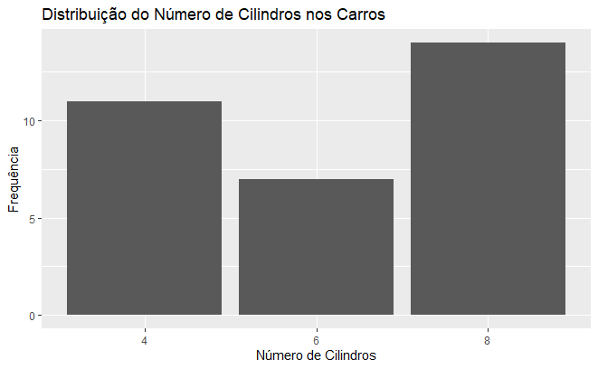

### Ordenando pela Frequência

Agora, vamos ordenar as barras pela frequência para visualizar melhor a distribuição.

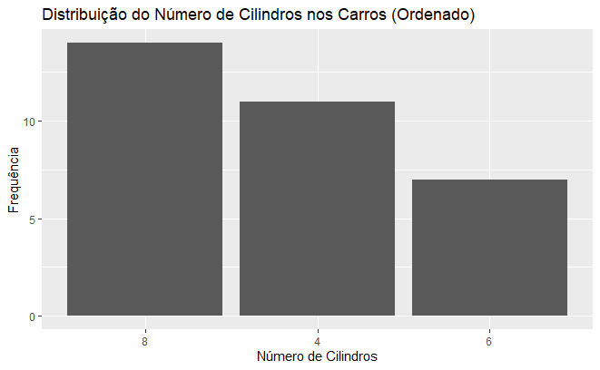

```r
# Ordenando pela frequência
ggplot(data = tb, mapping = aes(x = fct_infreq(cyl_factor))) +
    geom_bar() +
    labs(title = "Distribuição do Número de Cilindros nos Carros (Ordenado)", x = "Número de Cilindros", y = "Frequência")
```

Usamos a função `fct_infreq()` do pacote `forcats` para ordenar as categorias pela frequência, permitindo que as barras sejam apresentadas em ordem decrescente de frequência.

### Tabelas de Frequência

Podemos gerar uma tabela de frequência ao invés de um gráfico.

```r
# Tabela de frequência para o número de cilindros
tb %>% count(cyl_factor)
```

| cyl_factor | n |
| --- | --- |
| 4 | 11 |
| 6 | 7 |
| 8 | 14 |

Além da frequência absoluta, vamos calcular a frequência relativa e acumulada.

```r
# Tabela de frequência relativa e acumulada
tb %>%
  count(cyl_factor) %>%
  mutate(freq_relativa = n / sum(n),
         freq_acumulada = cumsum(freq_relativa))
```

| cyl_factor | n | freq_relativa | freq_acumulada |
| --- | --- | --- | --- |
| 4 | 11 | 0.34375 | 0.34375 |
| 6 | 7 | 0.21875 | 0.56250 |
| 8 | 14 | 0.43750 | 1.00000 |

## Análise Univariada para Variáveis Discretas

### Distribuição da Potência (hp)

Agora vamos analisar a distribuição da variável `hp` (potência), que foi categorizada em faixas.

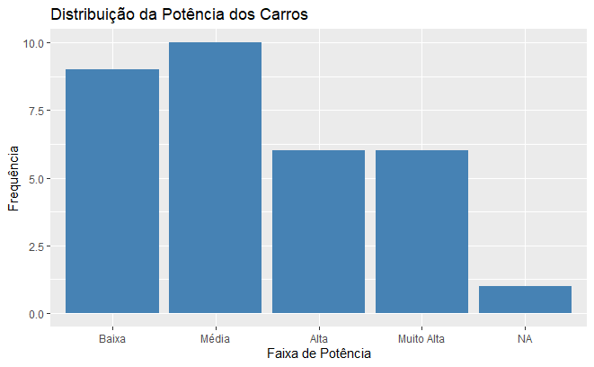

```r
# Gráfico de barras para a variável hp_group
ggplot(data = tb, mapping = aes(x = hp_group)) +
    geom_bar(fill = "steelblue") +
    labs(title = "Distribuição da Potência dos Carros", x = "Faixa de Potência", y = "Frequência")
```

Esse gráfico mostra a distribuição da potência dos carros, categorizada em faixas. Cada barra representa uma faixa de potência.

### Distribuição do Peso (wt)

Vamos fazer um gráfico de barras para visualizar a distribuição do peso (`wt`) dos carros, categorizando o peso em faixas.

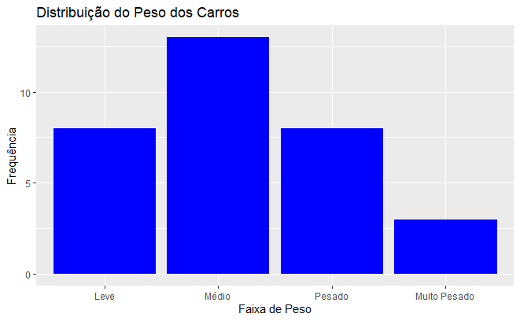

```r
# Categorizar o peso em faixas
tb <- tb %>%
  mutate(wt_group = cut(wt, breaks = c(1.5, 2.5, 3.5, 4.5, 5.5),
                        labels = c("Leve", "Médio", "Pesado", "Muito Pesado")))

# Gráfico de barras para a variável wt_group
ggplot(data = tb, mapping = aes(x = wt_group)) +
    geom_bar(fill = "blue") +
    labs(title = "Distribuição do Peso dos Carros", x = "Faixa de Peso", y = "Frequência")
```

Aqui, categorizamos o peso dos carros em quatro faixas e criamos um gráfico de barras para visualizar a distribuição.

### Criando uma Classe “>200 HP” para Potência

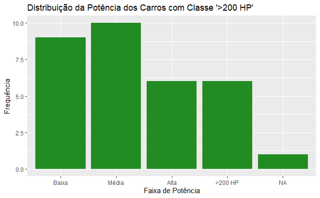

```r
tb <- tb %>%
  mutate(hp_group2 = fct_other(hp_group, keep = c("Baixa", "Média", "Alta"), other_level = ">200 HP"))

# Gráfico de barras para a nova variável hp_group2
ggplot(data = tb, mapping = aes(x = hp_group2)) +
    geom_bar(fill = "forestgreen") +
    labs(title = "Distribuição da Potência dos Carros com Classe '>200 HP'", x = "Faixa de Potência", y = "Frequência")
```

Usamos a função `fct_other()` para agrupar as categorias que não estão em “Baixa”, “Média”, ou “Alta” em uma nova classe “>200 HP”.

## Conclusão

Nesta aula, realizamos uma análise univariada de variáveis qualitativas e discretas utilizando a base de dados `mtcars`. Exploramos a distribuição das variáveis categóricas como o número de cilindros e categorizamos variáveis contínuas como a potência e o peso em faixas. Também vimos como criar novas classes para agrupar dados em categorias significativas.

Nas próximas aulas, continuaremos a explorar essa base de dados com análises mais complexas, utilizando outras funcionalidades do `ggplot2` e do `tidyverse`.